# **1. Basic lecture: 최적화 실습**

By Mingyu Lee and Ikjin Lee

http://idol.kaist.ac.kr/

mglee91@kaist.ac.kr

https://scholar.google.co.kr/citations?hl=ko&user=yDYefB8AAAAJ&view_op=list_works&sortby=pubdate

https://github.com/MingyuLee91

IDOL Lab at KAIST

### **< Contents >**

**1) Optimization example**

2) One-dimensional example (Kriging model)

3) One-dimensional example (Bayesian optimization)

4) Engineering application (Surrogate-based optimization)

## **▣ 최적화란?**

- 설계 영역내에서 제한조건을 만족시키면서 목적함수를 최소화 (or 최대화)하는 과정
- 최적화 알고리즘에 의해 설계 변수가 반복적으로 업데이트되어 최적해가 구해짐
- 다양한 최적화 알고리즘들이 존재 (Gradient-based optimization, heuristic optimization, surrogate-based optimization)

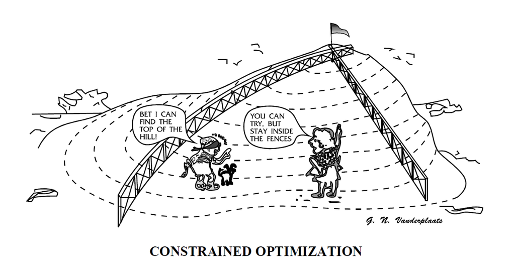

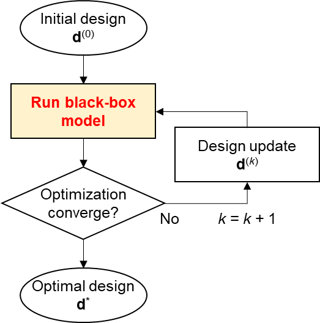

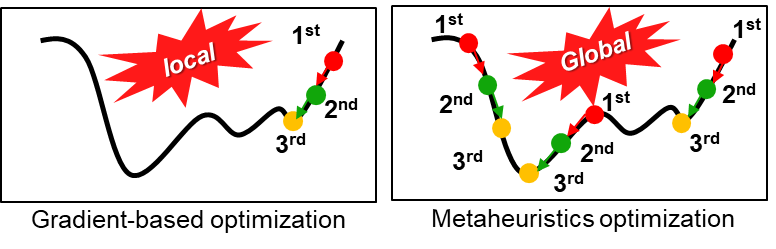

### **◎ Marker down 사용법 (주석)**

- Code를 Marker down으로 변경
- 작성하고 싶은 내용 입력
- ctrl + Enter으로 적용 완료  
  [참고자료] https://velog.io/@acacia__u/Markdown%EC%82%AC%EC%9A%A9%EB%B2%95%EC%B4%9D%EC%A0%95%EB%A6%AC

### **◎ Jupyter notebook 단축키 모음**

- Ctrl + /: 해당 셀 커서가 위치 된 곳 주석 처리, 주석처리 해제
- Ctrl + Enter: 해당 셀 실행  
  [참고자료] https://technical-support.tistory.com/58

### **◎ 참고 자료 (최적화 알고리즘 사용법)**

https://docs.scipy.org/doc/scipy/reference/optimize.html

### ※ **예제 문제 (Unconstrained optimization)**

- 설계 공간: 0~1
- 목적 함수: obj = (6x - 2)<sup>2</sup> sin(12x - 4)를 최소화
- 제한 조건: 없음
- 다양한 초기값과 최적화 알고리즘을 적용하여 최적화 결과 비교해보기
- True 최적해: x<sub>opt</sub> = 0.75724875, obj<sub>opt</sub> = -6.02074006

```python
from scipy.optimize import minimize, differential_evolution
import numpy as np
import matplotlib.pyplot as plt
```

```python
def obj(x): # 목적함수 (함수 이름은 자유롭게 설정 가능)
    return ((6*x-2)**2)*np.sin((6*x-2)*2) # x를 입력했을때 나오는 함수 값
```

```python
def constr(x): # 제한조건함수
    return 0
```

```python
bnds = [(0,1)] # 경계값 (설계 공간)
```

```python
ineq_cons = {'type': 'ineq', 'fun': constr} # 제한조건 설정 (기본 설정)
```

```python
initial_points = np.array([0.0], dtype = 'float64') # 초기값 (사용자가 설정해야함)
```

```python
print("Initial input",initial_points)
print("Initial obj",obj(initial_points))
```

```
Initial input [0.]
Initial obj [3.02720998]
```

```python
# 최적화 수행
result = minimize(obj,initial_points,method="SLSQP",bounds=bnds,constraints=ineq_cons) # Gradient-based optimization
# result = differential_evolution(obj,bnds) # Metaheuristic optimization
```

```python
result
```

```
 message: Optimization terminated successfully
 success: True
  status: 0
     fun: 4.733661906617304e-07
       x: [ 3.344e-01]
     nit: 10
     jac: [ 1.377e-03]
    nfev: 21
    njev: 10
```

```python
x_opt = result.x
f_opt = result.fun
# constr(result.x)
print("Optimal input",x_opt)
print("Minimum",f_opt)
```

```
Optimal input [0.33436429]
Minimum 4.733661906617304e-07
```

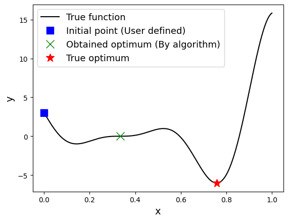

```python
# 시각화 (Post-processing)
num = 1000
x = np.linspace(0.0, 1.0, num) # 0에서 1까지 등간격으로 num개의 x값을 생성

y_true = obj(x)

# add a plot with variance
fig, axs = plt.subplots(1)
axs.plot(x, y_true,"k") # 실제함수
axs.plot(initial_points, obj(initial_points), "bs", markersize = 10) # 초기해
axs.plot(x_opt, f_opt, "gx", markersize = 12) # 알고리즘을 통해 구한 최적해
axs.plot(0.75724875, -6.02074006, "r*", markersize = 12) # 실제 최적해

axs.set_xlabel("x",fontsize="14")
axs.set_ylabel("y",fontsize="14")
axs.legend(
    ["True function","Initial point (User defined)","Obtained optimum (By algorithm)","True optimum"],
    loc="best",fontsize="13",
)
plt.show()
```